# Variable Telicity in Verbs of Consumption

Jesus Adolfo Hermosillo

5/27/2021

# Variable Telicity in Verbs of Consumption

Experimental work has found that consumption verbs tend to allow for non-maximal interpretations. That is, an event of consumption is interpreted as true even when the event has not reached a maximal culmination.

In this experiment, we investigate how event progression and maximality of quantized direct objects interact to produce various response patterns regarding telic interpretations in verbs of consumption.

Our hypothesis is that rather than a partitive atelic meaning, consumption verb predicates have a non-partitive telic meaning, but a number of factors can contribute to a relaxation of its culmination entailments.

Our predictions are the following:

-Predicates will be interpreted as telic less often when event progressions are closer to a maximal culmination. In other words, culmination entailments will be relaxed the closer the event progression is to a maximal culmination.

-Predicates will be interpreted as telic more often when they have a maximal quantized direct object than when they have a non-maximal quantized direct object. That is, culmination entailments will be relaxed more for predicates with non-maximal quantized direct objects than for those with maximal quantized direct objects.

:

```r
data <- read.csv(file = '/Users/jesushermosillo/Desktop/pilot/language_experiment-merged_pilot.csv')

library(ggplot2)
library(tidyverse)
library(lme4)
```

## Response tallies for predicates based maximality of quantized direct objects.

The pink bars represent a participants rejection of a sentence, the blue bars represent participants acceptance of a sentence. Participants tend to reject sentences more for maximal DOs, Participants tend to accept sentences more for the non-maximal DOs :

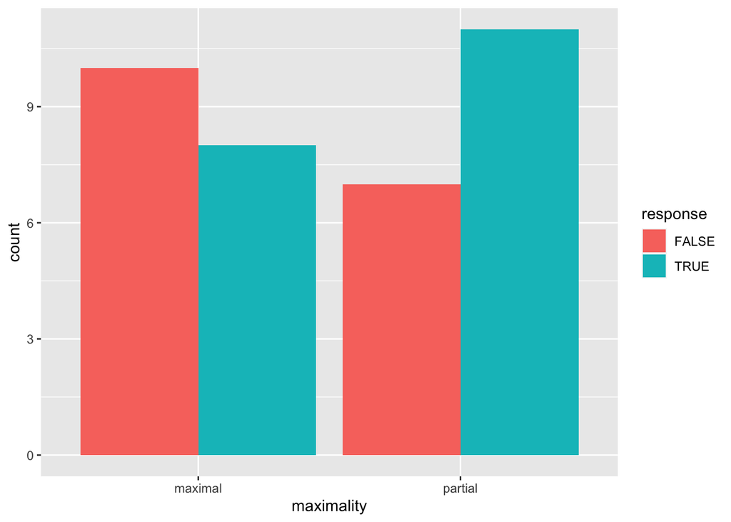

```r
ggplot(data[data$item_type=='critical',], aes(x =maximality,  fill = response)) + geom_bar(position = "dodge")
```

## Response tallies for predicates based event progression.

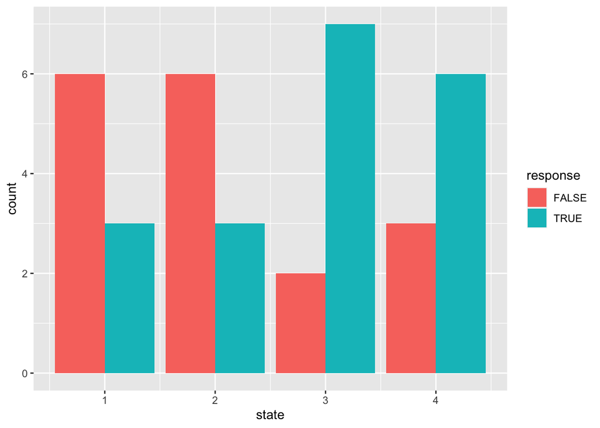

```r
ggplot(data[data$item_type=='critical',], aes(x =state,  fill = response)) + geom_bar(position = "dodge")
```